# P8105 - Homework 1

Mingkuan Xu

### Problem 1

Create a data frame comprised of:

- a random sample of size 10 from a standard Normal distribution
- a logical vector indicating whether elements of the sample are greater than 0
- a character vector of length 10
- a factor vector of length 10, with 3 different factor “levels”

```r
set.seed(124) # Set a random seed

# Generate a random normal distributed sample of size 10
sample <- rnorm(10)

# Add the sample to a dataframe with column name random_values
df <- data.frame(random_values = sample)

# Add a new column named is_positive indicating whether elements of the sample are greater than 0
df$is_positive <- with(df,ifelse(random_values>0,TRUE,FALSE))

# Create a character vector of length 10 and name it character_vector
df$character_vector = vector("character", length = 10)

# Create a factor vector with 3 different factor “levels”, and name it factor_vector
df$factor_vector = factor(c(1,2,2,3,1,2,3,3,1,2))
```

Try to take the mean of each variable in your dataframe. What works and what doesn’t?

Hint: to take the mean of a variable in a dataframe, you need to pull the variable out of the dataframe. Try loading the tidyverse and using the pull function.

```r
# We can use the pull function from tidyverse as instructed.

library(tidyverse) # Load tidyverse library
mean(pull(df,random_values)) # Find the mean of numeric vector
```

```
## [1] 0.2147669
```

```r
mean(pull(df,is_positive)) # Find the mean of logical vector
```

```
## [1] 0.7
```

```r
mean(pull(df,character_vector)) # Find the mean of character vector
```

```
## [1] NA
```

```r
mean(pull(df,factor_vector)) # # Find the mean of factor vector
```

```
## [1] NA
```

**By running the code, we could see it works for the numeric and logical vectors, but fails for the character and factor vectors.**

In some cases, you can explicitly convert variables from one type to another. Write a code chunk that applies the as.numeric function to the logical, character, and factor variables (please show this chunk but not the output).

```r
as.numeric(df$is_positive)
as.numeric(df$character_vector)
as.numeric(df$factor_vector)
```

What happens, and why? Does this help explain what happens when you try to take the mean?

**For the logical vector, as.numeric transforms it to a vector with values 0 (for FALSE) or 1 (for TRUE), which explains how R is able to find the mean of this vector.**

**For the character vector, as.numeric transforms it to multiple NAs. This also explains why there cannot be a “mean” value of character vecter, because characters cannot be automatically transformed into numbers in R.**

### Problem 2

Use the following code (in your RMarkdown file) to load the penguins dataset:

```r
data("penguins", package = "palmerpenguins")
```

Write a short description of the penguins dataset (not the penguins_raw dataset) using inline R code, including: - The data in this dataset, including names / values of important variables - The size of the dataset (using nrow and ncol) - The mean flipper length

**This dataset describes the information of some penguins, including their species, island, bill_length_mm, bill_depth_mm, flipper_length_mm, body_mass_g, sex, year. Typical species includes Adelie, Gentoo, Chinstrap. Typical islands found includes Torgersen, Biscoe, Dream. The dataset has 344 rows and 8 columns. After removing all the NA valules, the mean flipper length is 200.9152047 mm.**

Make a scatterplot of flipper_length_mm (y) vs bill_length_mm (x); color points using the species variable (adding color = … inside of aes in your ggplot code should help).

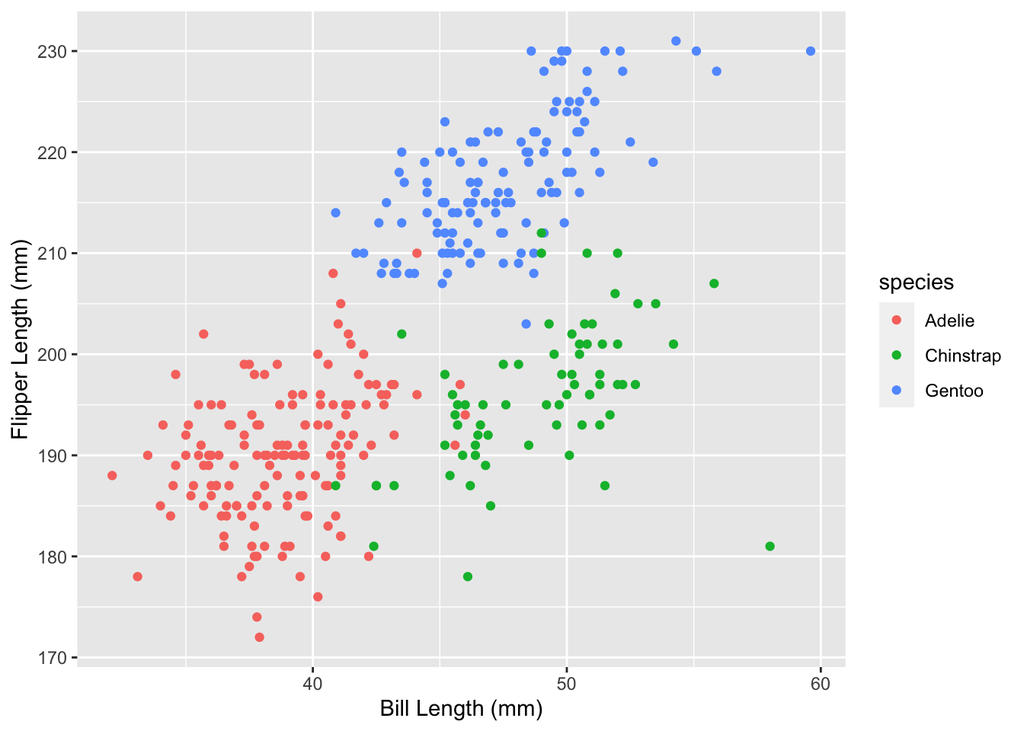

```r
ggplot(penguins,aes(x=bill_length_mm, y=flipper_length_mm,color=species))+
    geom_point()+
  labs(x="Bill Length (mm)",y="Flipper Length (mm)")
```

Export your first scatterplot to your project directory using ggsave.

```r
ggsave(file="./output.pdf")
```